# Lab-08

# Part 7: Find Optimal Model

We can the tune function to find the optimal cost parameter.

```r
set.seed(1)

# range of cost values
costs <- c(0.001,0.01,0.1,1,5,10,100,1000,10000,1e5)

tuned_fit = tune(svm, y~., data = data ,kernel="linear",ranges=list(costs))


summary(tuned_fit)
```

```
##
## Parameter tuning of 'svm':
##
## - sampling method: 10-fold cross validation
##
## - best parameters:
##   Var1
##  0.001
##
## - best performance: 0.03
##
## - Detailed performance results:
##     Var1 error dispersion
## 1  1e-03  0.03  0.0421637
## 2  1e-02  0.03  0.0421637
## 3  1e-01  0.03  0.0421637
## 4  1e+00  0.03  0.0421637
## 5  5e+00  0.03  0.0421637
## 6  1e+01  0.03  0.0421637
## 7  1e+02  0.03  0.0421637
## 8  1e+03  0.03  0.0421637
## 9  1e+04  0.03  0.0421637
## 10 1e+05  0.03  0.0421637
```

The optimal cost parameter is 0.001.

# SVM on Linear inseparable dataset

## Generate Linear inseparable dataset

```r
# Set seed
set.seed(300)

# half and half with different means
positive_1 <- matrix(rnorm((data_points/2), mean = pos_mean), nrow = 50, ncol = 2)

positive_2 <- matrix(rnorm((data_points/2), mean = neg_mean), nrow = 50, ncol = 2)


set.seed(300)


negative_1 = matrix(c(rnorm((data_points/2),mean = neg_mean) + 3,
                      rnorm((data_points/2),mean = neg_mean)),nrow = 50,ncol = 2)

negative_2 = matrix(c(rnorm((data_points/2),mean = pos_mean) - 3,
                      rnorm((data_points/2),mean = pos_mean)),nrow = 50,ncol = 2)
```

We will again create simulated labels for our new dataset.

```r
new_labels <- c(rep(1, 100), rep(-1, 100))
```

And again, we will bind and populate a dataframe.

```r
new_obs <- rbind(positive_1, positive_2, negative_1, negative_2)

new_data <- data.frame(x = new_obs, y = as.factor(new_labels))
```

We visulaise our dataset.

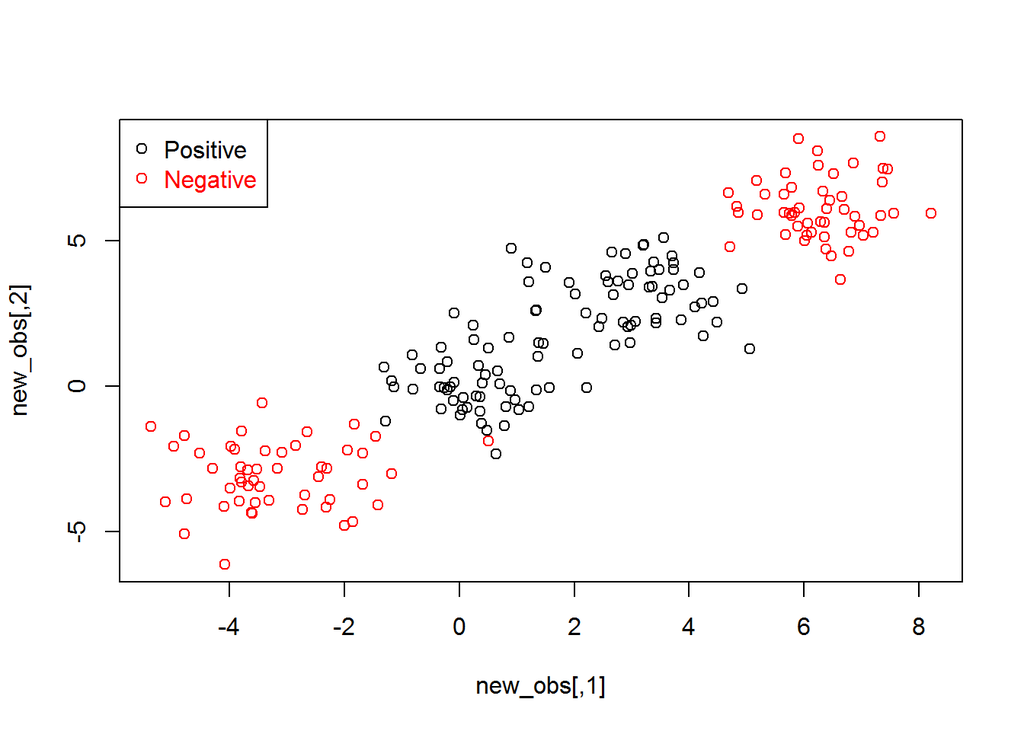

```r
plot(new_obs, col=ifelse(new_labels > 0, 1, 2))
legend("topleft",c("Positive","Negative"),col=seq(2),pch=1,text.col=seq(2))
```

Finally we can again split our data into training and test sets by a 70/30 split.

```r
set.seed(300)

new_train_indices <- sample(200, 200 * 0.7)

new_training_set <- new_data[new_train_indices, ]

new_test_obs <- obs[-new_train_indices, ]
new_test_labels <- labels[-new_train_indices]
```

# Part 8: SVM model with a radial kernel, gamma =1 and cost = 1.

To deal with our linear inseparable dataset, we will build a radial model, with a cost of 1 and gamma parameter also of 1.

```r
non_linear_fit_1 = svm(y~.,data = new_training_set, kernel = "radial",gamma = 1, cost = 1)
```

### a: Summary

```r
summary(non_linear_fit_1)
```

```
##
## Call:
## svm(formula = y ~ ., data = new_training_set, kernel = "radial",
##     gamma = 1, cost = 1)
##
##
## Parameters:
##    SVM-Type:  C-classification
##  SVM-Kernel:  radial
##        cost:  1
##       gamma:  1
##
## Number of Support Vectors:  23
##
##  ( 11 12 )
##
##
## Number of Classes:  2
##
## Levels:
##  -1 1
```

### b: Plot

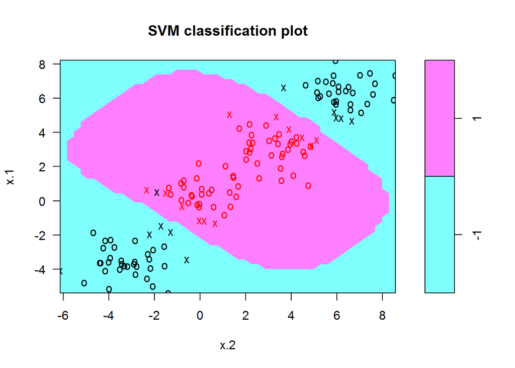

```r
plot(non_linear_fit_1, new_training_set)
```

### C: Test error

```r
# predictions
prediction_non_linear_1 = predict(non_linear_fit_1, newdata = new_test_obs)

# error calculation
mean(prediction_non_linear_1 != new_test_labels)
```

```
## [1] 0.5
```

The model has and error of 0.5.

## Part 9: SVM model with a radial kernel, gamma =1 and cost = 1e5.

```r
# build model
non_linear_fit_1e5 = svm(y~.,data = new_training_set, kernel = "radial",gamma = 1,cost = 1e5)
```

### a: Summary

```r
summary(non_linear_fit_1e5)
```

```
##
## Call:
## svm(formula = y ~ ., data = new_training_set, kernel = "radial",
##     gamma = 1, cost = 1e+05)
##
##
## Parameters:
##    SVM-Type:  C-classification
##  SVM-Kernel:  radial
##        cost:  1e+05
##       gamma:  1
##
## Number of Support Vectors:  9
##
##  ( 6 3 )
##
##
## Number of Classes:  2
##
## Levels:
##  -1 1
```

### b: Plot

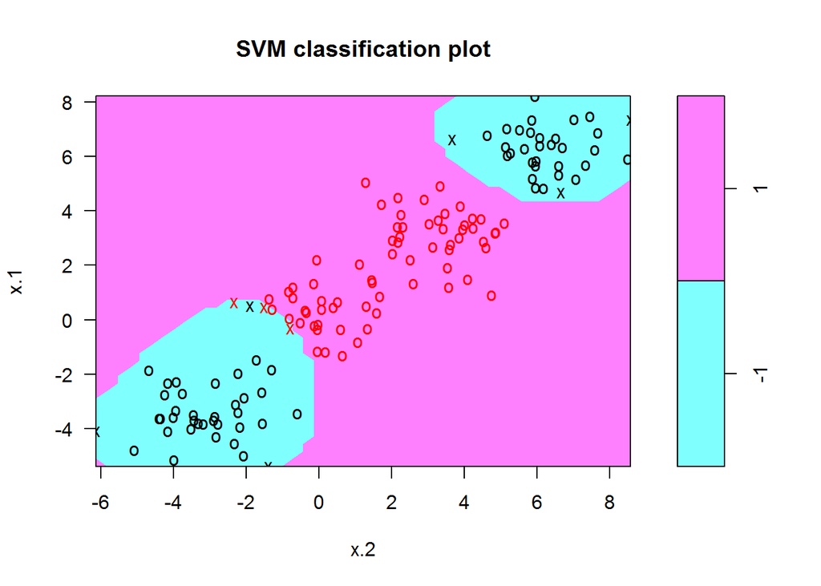

```r
plot(non_linear_fit_1e5, new_training_set)
```

### C: Test error

```r
# predictions
prediction_non_linear_1e5 = predict(non_linear_fit_1e5, newdata = new_test_obs)

# error calculation
mean(prediction_non_linear_1e5 != new_test_labels)
```

```
## [1] 0.5833333
```

# Part 10: Optimal values for cost and gamma

We can use the tune function to find the optimal values for both parameters.

```r
set.seed(1)

costs <- c(0.001,0.01,0.1,1,5,10,100,1000,10000,1e5)

gammas <- c(0.5, 1, 1.5, 2, 2.5, 3, 3.5, 4)

tuned_radial <- tune(svm,y~.,data = new_training_set, kernel = "radial",ranges = list(cost = costs, gamma = gammas))
```

Summarise the results.

```r
summary(tuned_radial)
```

```
##
## Parameter tuning of 'svm':
##
## - sampling method: 10-fold cross validation
##
## - best parameters:
##  cost gamma
##   0.1   0.5
##
## - best performance: 0.007142857
##
## - Detailed performance results:
##     cost gamma       error dispersion
## 1  1e-03   0.5 0.571428571 0.19047619
## 2  1e-02   0.5 0.571428571 0.19047619
```

[output cut: 78 more lines]

We can see that the best value for cost is 0.1 and the best value for gamma is 0.5.

## Part 11: Test error on optimal model

Finally, we can check the test error on our optimal model.

```r
prediction_optimal_radial = predict(tuned_radial$best.model, newdata = new_test_obs)

mean(prediction_optimal_radial != new_test_labels)
```

```
## [1] 0.5
```